# Problem Set 3 - Boston

SI 544 Instruction Team

11/15/2019

## Introduction

The total score for this assignment will be 100 points, consisting of: - 90 points: Homework Questions - 10 points: Overall quality of spelling, grammar, punctuation, etc. of written sentences.

As in lecture and discussion, there are several ways to approach and answer these questions! There may not be a “best solution”, but instead a variety of ways to interpret and analyze a given task. Be thoughtful in your responses below your code to explain why you chose the methods and representations in your analysis when prompted for a response.

For further reference regarding quality writing, feel free to refer to Strunk & White’s Elements of Style: https://drive.google.com/file/d/1L0P7xJwjUGBvyb49mL3dw1Bt7hzRTiTl/view?usp=sharing

## The Data

The dataset for this assignment was gathered in 1970 in the Boston metropolitan area. Each row corresponds to one US Census tract. These are geographic areas with a few thousand people used by the U.S. government in it’s decennial census of the population. (The help menu entry refers to “towns” in a few places. These should read “census tracts”.) The dataset is the Boston dataset in the MASS package.

Note that the set of entries here is *not* a sample of a larger population of Boston census tracts. It represents all census tracts in Boston (Though each entry itself may be a sample of the larger population in that tract.) We also can not say that Boston represents the entire US, since regions differ. For our purposes, let us assume that these census tracts are a sample of all census tracts in urban areas in the northeastern United States.

```r
## First load some packages and the data. You may have to install the MASS package first.
## Also, note the package load order matters here. MASS and dplyr both have a select function. If you want to use dplyr's select, we need to run it last.
library(MASS)
library(tidyverse)
library(skimr)
library(infer)
library(moderndive)
boston <- Boston
```

### Question 1 (10 Points)

Take a look at the data using one or more of the exploratory data analysis tools and techniques that you’ve learned in SI 544. Make sure to look at the help menu to understand the variables.

Describe the shape of the distribution of the per capita crime rates. What does this say about crime and geography in Boston?

```r
glimpse(boston)
```

```
## Observations: 506
## Variables: 14
## $ crim    <dbl> 0.00632, 0.02731, 0.02729, 0.03237, 0.06905, 0.02985, 0.…
## $ zn      <dbl> 18.0, 0.0, 0.0, 0.0, 0.0, 0.0, 12.5, 12.5, 12.5, 12.5, 1…
## $ indus   <dbl> 2.31, 7.07, 7.07, 2.18, 2.18, 2.18, 7.87, 7.87, 7.87, 7.…
## $ chas    <int> 0, 0, 0, 0, 0, 0, 0, 0, 0, 0, 0, 0, 0, 0, 0, 0, 0, 0, 0,…
## $ nox     <dbl> 0.538, 0.469, 0.469, 0.458, 0.458, 0.458, 0.524, 0.524, …
## $ rm      <dbl> 6.575, 6.421, 7.185, 6.998, 7.147, 6.430, 6.012, 6.172, …
## $ age     <dbl> 65.2, 78.9, 61.1, 45.8, 54.2, 58.7, 66.6, 96.1, 100.0, 8…
## $ dis     <dbl> 4.0900, 4.9671, 4.9671, 6.0622, 6.0622, 6.0622, 5.5605, …
## $ rad     <int> 1, 2, 2, 3, 3, 3, 5, 5, 5, 5, 5, 5, 5, 4, 4, 4, 4, 4, 4,…
## $ tax     <dbl> 296, 242, 242, 222, 222, 222, 311, 311, 311, 311, 311, 3…
## $ ptratio <dbl> 15.3, 17.8, 17.8, 18.7, 18.7, 18.7, 15.2, 15.2, 15.2, 15…
## $ black   <dbl> 396.90, 396.90, 392.83, 394.63, 396.90, 394.12, 395.60, …
## $ lstat   <dbl> 4.98, 9.14, 4.03, 2.94, 5.33, 5.21, 12.43, 19.15, 29.93,…
## $ medv    <dbl> 24.0, 21.6, 34.7, 33.4, 36.2, 28.7, 22.9, 27.1, 16.5, 18…
```

```r
boston %>% summarise(max_val = max(crim), min_value = min(crim))
```

```
##   max_val min_value
## 1 88.9762   0.00632
```

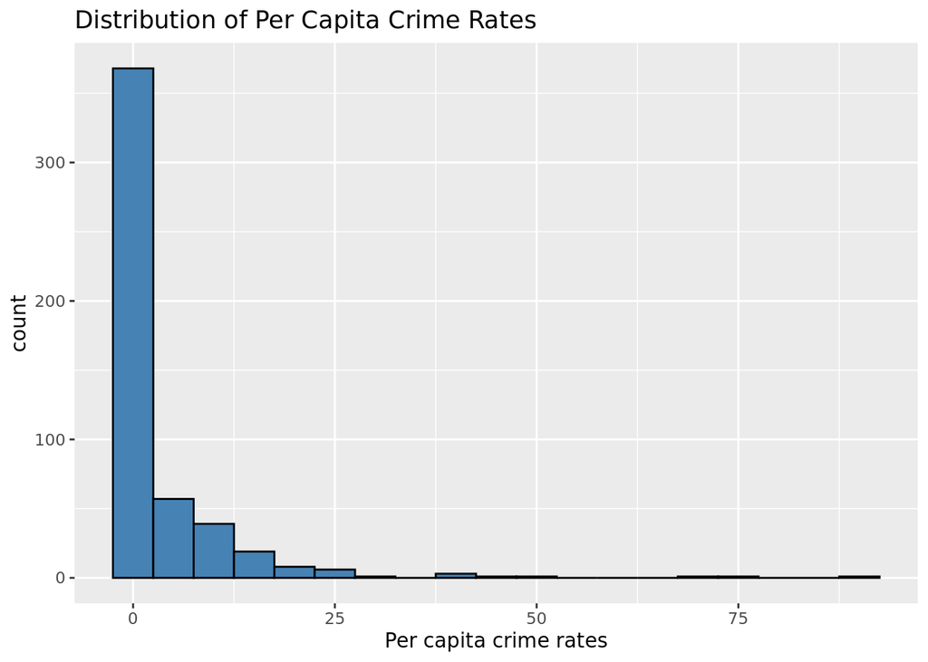

```r
ggplot(data = boston, mapping = aes(x = crim))+
  labs(title = 'Distribution of Per Capita Crime Rates', x = 'Per capita crime rates')+
  geom_histogram(bins = 30, binwidth = 5, color = 'black', fill = 'steelblue')
```

### Question 2 (10 Points)

Use bootstrapping with the percentile method to compute a 95% confidence interval for the average pupil-teacher ratio in urban, northeastern United States. Interpret your results in a complete sentence that a non-statistician would understand.

```r
boston %>%  summarize(stat = mean(ptratio))
```

```
##       stat
## 1 18.45553
```

```r
bootstrap_distribution_boston <- boston %>%
  specify(response = ptratio) %>% generate(reps = 1000, replace = TRUE, type="bootstrap") %>% calculate(stat = "mean")

bootstrap_distribution_boston
```

```
## # A tibble: 1,000 x 2
##    replicate  stat
##        <int> <dbl>
##  1         1  18.4
##  2         2  18.4
##  3         3  18.5
##  4         4  18.4
##  5         5  18.4
##  6         6  18.5
##  7         7  18.4
##  8         8  18.4
##  9         9  18.4
## 10        10  18.4
## # … with 990 more rows
```

```r
percentile_ci_boston <- bootstrap_distribution_boston %>%
  get_confidence_interval(level = 0.95, type = "percentile")

percentile_ci_boston
```

```
## # A tibble: 1 x 2
##   `2.5%` `97.5%`
##    <dbl>   <dbl>
## 1   18.3    18.6
```

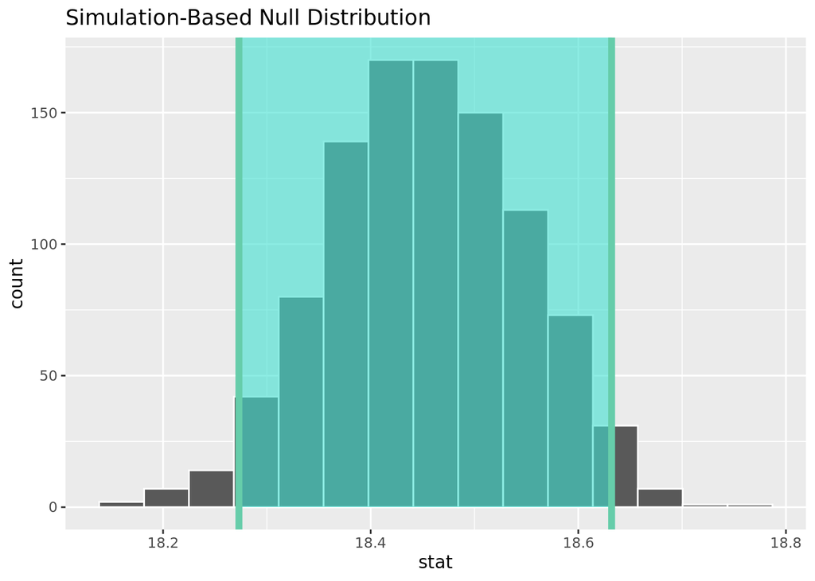

```r
visualise(bootstrap_distribution_boston) +
  shade_confidence_interval(endpoints = percentile_ci_boston)
```

#### Q2 Response

I’m 95% confident that the average of the number of pupil upon number of teacher, i.e; average pupil-teacher ratio in urban, northeastern US (Boston) is between 18.26 and 18.64.

### Question 3 (10 Points)

Use the traditional method, using a t-distribution, to compute a 95% confidence interval for the average pupil-teacher ratio in urban, northeastern United States. (You can use t*=1.96.)

```r
boston %>%  summarize(stat = mean(ptratio), std_dev = sd(ptratio))
```

```
##       stat  std_dev
## 1 18.45553 2.164946
```

n = 506 mean = 18.45553 s = 2.1649 t*=1.96 SE = s/n^1/2 = 0.0962 ME = t* SE

CI with mean = mean +/- ME CI = [18.2667, 18.6439]

#### Q3 Response

I’m 95% confident that the average pupil-teacher ratio in urban, northeastern US (Boston) is between 18.2667 and 18.6439.

### Question 4 (10 Points)

Assume that urban northeastern US property tax rates are currently around 1.054%. (Actually, this is Boston. Just go with it.) We would like to know if urban northeastern US property tax rates are higher today than they were in 1970.

Set up (but don’t run it yet) a hypothesis test to examine this question. What are your null and alternative hypotheses? What is the cut-off for a p-value that you will use to reject the null?

#### Q4 Response

Null Hypothesis: The property tax rates in 1970 in Boston are 1.054%.

Alternative Hypothesis: The property tax rates in 1970 in Boston are lower than 1.054%.

Cut-off p-value (alpha): 0.05

### Question 5 (10 Points)

Use the traditional method, with a test-statistic, to calculate the p-value for the hypothesis test you wrote out in Question 4. Write your conclusion in a few complete sentences that would make sense to a random Boston citizen.

```r
boston_tax <- boston %>% mutate(tax_rate = tax/100)

boston_tax %>% summarize(mean_tax = mean(tax_rate), std_tax = sd(tax_rate))
```

```
##   mean_tax  std_tax
## 1 4.082372 1.685371
```

```r
t.test(boston_tax$tax_rate, mu = 1.054, alternative = "less")
```

```
##
##  One Sample t-test
##
## data:  boston_tax$tax_rate
## t = 40.419, df = 505, p-value = 1
## alternative hypothesis: true mean is less than 1.054
## 95 percent confidence interval:
##      -Inf 4.205837
## sample estimates:
## mean of x
##  4.082372
```

```r
pt(40.41979, 505)
```

```
## [1] 1
```

#### Q5 Response

n = 506 x-bar = 4.082372 mu= 1.054 s = 1.685371 SE = s/n^1/2 = 0.074923 df = n-1 = 505

t = [(x-bar) - mu]/SE = 40.41979

### Question 6 (10 Points)

Use the infer package to calculate the p-value for the hypothesis test you wrote out in Question 4. Write your conclusion in a few complete sentences that would make sense to a random Boston citizen. Hint: Look at the ModernDive textbook, Appendix B.2.4.

```r
boston_tax %>% summarize(stat = mean(tax_rate), Md_tx = median(tax_rate))
```

```
##       stat Md_tx
## 1 4.082372   3.3
```

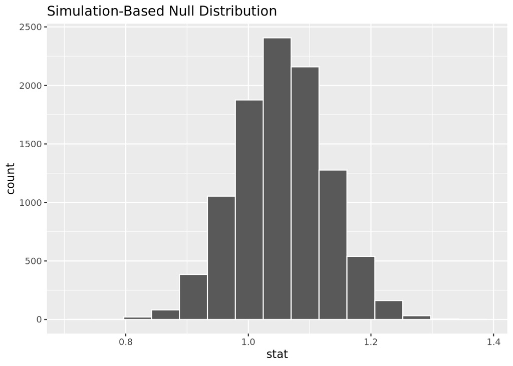

```r
null_dist <- boston_tax %>% specify(response = tax_rate) %>% hypothesize(null = "point", mu = 1.054 ) %>% generate(reps = 10000, type = "bootstrap") %>% calculate(stat = "mean")

null_dist %>% visualize()
```

```r
x_bar <- boston_tax %>% specify(response = tax_rate) %>% calculate(stat = "mean")

x_bar
```

```
## # A tibble: 1 x 1
##    stat
##   <dbl>
## 1  4.08
```

```r
pval <- null_dist %>% get_pvalue(obs_stat = 1.054, direction = "less")

pval
```

```
## # A tibble: 1 x 1
##   p_value
##     <dbl>
## 1   0.503
```

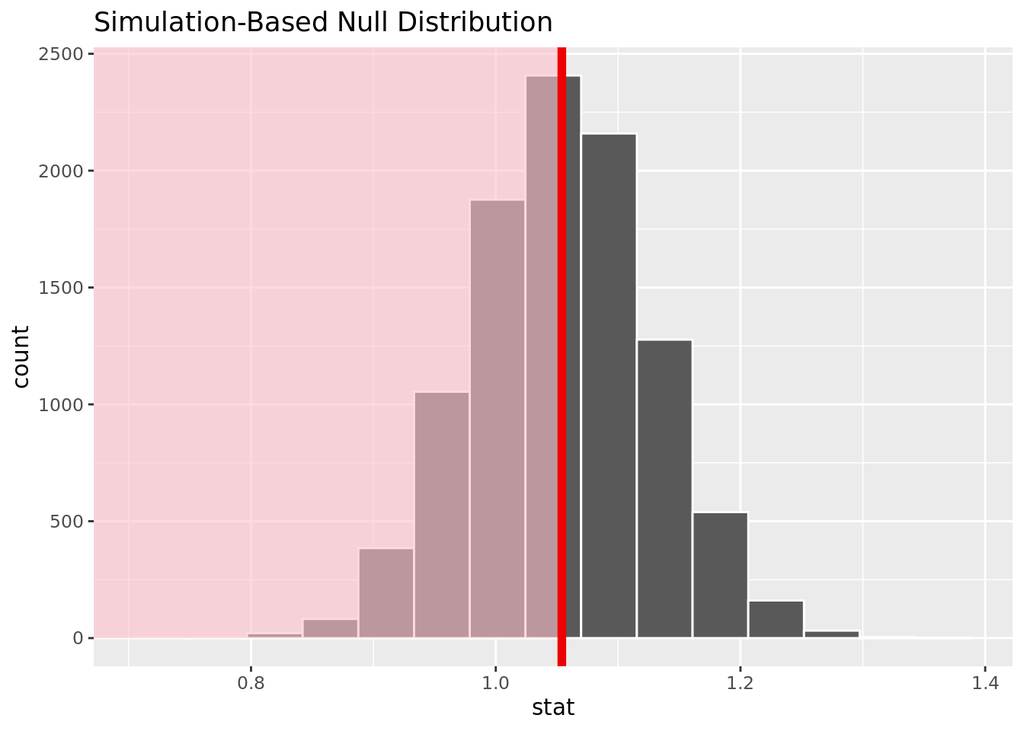

```r
visualize(null_dist) + shade_p_value(obs_stat = 1.054, direction = "less")
```

### Question 7 (10 Points)

Now we are curious about what traits are related to high-crime areas. Run a regression that predicts per capita crime rate based on the following variables: zn, chas, nox, rm, age, dis, and rad.

1. Make sure that your regression table or regression summary is visible in your knit document. (b) Which variables don’t seem to be (statistically significantly) related to per capita crime rates? Write your answer in sentences that would make sense to a random Boston citizen. (c) What is the R^2 value?

```r
b1 <- lm(crim ~ zn+chas+nox+rm+age+dis+rad, data = boston)
get_regression_table(b1)
```

```
## # A tibble: 8 x 7
##   term      estimate std_error statistic p_value lower_ci upper_ci
##   <chr>        <dbl>     <dbl>     <dbl>   <dbl>    <dbl>    <dbl>
## 1 intercept    9.47      4.64       2.04   0.042    0.352   18.6
## 2 zn           0.044     0.018      2.48   0.014    0.009    0.078
## 3 chas        -1.80      1.18      -1.52   0.128   -4.11     0.519
## 4 nox         -4.90      4.74      -1.03   0.303  -14.2      4.43
## 5 rm          -1.25      0.458     -2.73   0.006   -2.15    -0.352
## 6 age          0.021     0.017      1.23   0.221   -0.013    0.055
## 7 dis         -0.652     0.269     -2.42   0.016   -1.18    -0.124
## 8 rad          0.564     0.043     13.1    0        0.479    0.648
```

```r
get_regression_summaries(b1)
```

```
## # A tibble: 1 x 8
##   r_squared adj_r_squared   mse  rmse sigma statistic p_value    df
##       <dbl>         <dbl> <dbl> <dbl> <dbl>     <dbl>   <dbl> <dbl>
## 1     0.416         0.407  43.1  6.57  6.62      50.6       0     8
```

#### Q7 Response

The R^2 value is 0.416.

### Question 8 (10 Points)

Remember how the distribution of per capita crime looked? This means that the data is right-skewed. In cases like this we might try log-transforming the data. If we find a stronger statistical relationship with the log-transformed data, then there might be an exponential process that generated the original data. (Because logarithms undo exponents.) For example if you suspect that the relationship between variables x and y is $y=a*b^x$, then the log-transformed equation is $log(y)=log(a)+x*log(b)$ or, rewriting the constants, $log(y)=A + Bx$. So x and log(y) will be linearly related, and we can do a linear regression. For more more details on logarithms, you can check out: https://www.statisticshowto.datasciencecentral.com/probability-and-statistics/statistics-definitions/logarithms/

Create a new variable in the boston data frame called log_crim. This should be the natural logarithm of the per capita crime rate. Then run the regression that you ran in the previous problem, except replace crim with log_crim.

1. Make sure that your regression table or regression summary is visible in your knit document. (b) Which variables don’t seem to be (statistically significantly) related to the logarithm of per capita crime rates? Write your answer in sentences that would make sense to a random Boston citizen.

```r
boston_new <- boston %>% mutate(log_crim = log(crim))
boston_new
```

[output not shown]

[output cut: 999 more lines]

```r
B1 <- lm(log_crim ~ zn+chas+nox+rm+age+dis+rad, data = boston_new)
get_regression_table(B1)
```

```
## # A tibble: 8 x 7
##   term      estimate std_error statistic p_value lower_ci upper_ci
##   <chr>        <dbl>     <dbl>     <dbl>   <dbl>    <dbl>    <dbl>
## 1 intercept   -4.38      0.559    -7.83    0       -5.47    -3.28
## 2 zn          -0.01      0.002    -4.51    0       -0.014   -0.005
## 3 chas        -0.036     0.142    -0.256   0.798   -0.315    0.242
## 4 nox          4.82      0.571     8.44    0        3.70     5.94
## 5 rm          -0.123     0.055    -2.23    0.026   -0.231   -0.015
## 6 age          0.008     0.002     3.91    0        0.004    0.012
## 7 dis         -0.038     0.032    -1.18    0.24    -0.102    0.025
## 8 rad          0.146     0.005    28.2     0        0.136    0.156
```

```r
get_regression_summaries(B1)
```

```
## # A tibble: 1 x 8
##   r_squared adj_r_squared   mse  rmse sigma statistic p_value    df
##       <dbl>         <dbl> <dbl> <dbl> <dbl>     <dbl>   <dbl> <dbl>
## 1     0.866         0.864 0.625 0.791 0.797      460.       0     8
```

#### Q8 Response

The R^2 value is 0.866.

### Question 9 (10 points)

Compare the R^2 values of the two regressions from Q7 and Q8. Which regression seems to have a stronger relationship? Should we use crim or log_crim in future analysis? (You should also be able to support your explanation by looking at graphs of the residuals for each regression. Though you don’t have to do that here.)

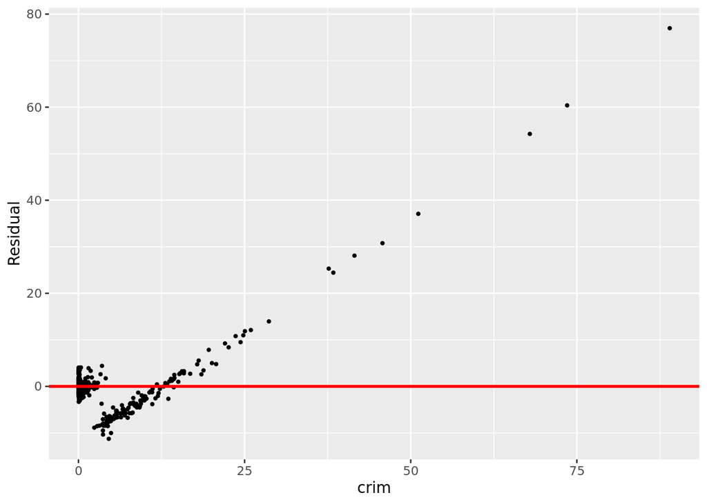

```r
b1_regression_points <- get_regression_points(b1)
ggplot(b1_regression_points, aes(x = crim, y = residual)) +
  geom_point(size = 0.8) +
  labs(x = "crim", y = "Residual") + geom_hline(yintercept = 0, col = "red", size = 1)
```

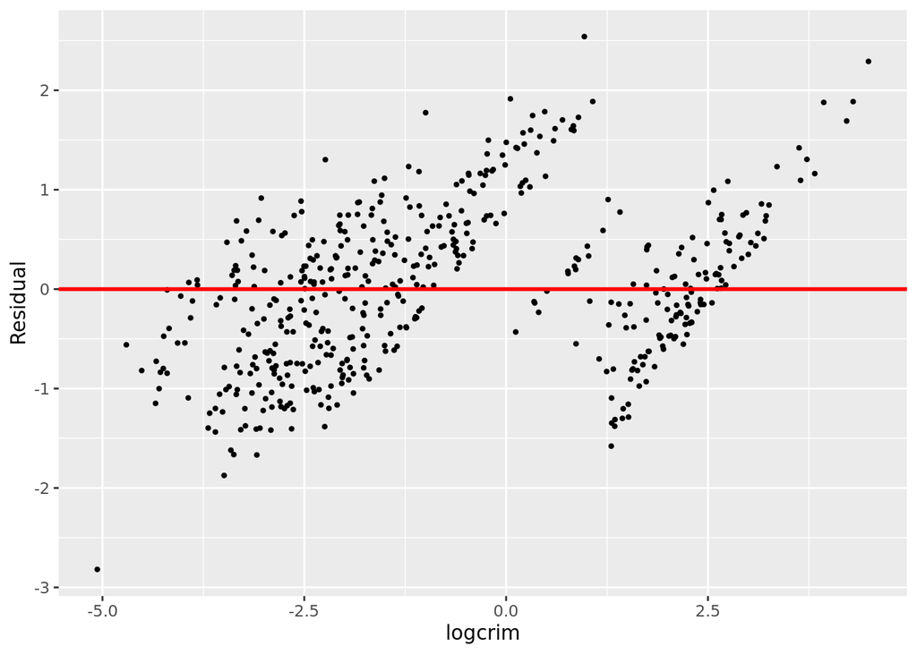

```r
B1_regression_points <- get_regression_points(B1)
ggplot(B1_regression_points, aes(x = log_crim, y = residual)) +
  geom_point(size = 0.8) +
  labs(x = "logcrim", y = "Residual") + geom_hline(yintercept = 0, col = "red", size = 1)
```

#### Q9 Response

Since the R^2 value of B1 is greater than R^2 value of b1 and more closer to 1, the regression model of log_crim seems to have stronger relationship. The regression predictions of B1 model is a better fit than of b1 model. Therefore, we should use log_crim for future analysis.